# EV Report

Stefan Ofili

2025-06-13

# Fundamental EV Report

## Introduction

For a deeper dive into consumer sentiment, political dynamics, and more detailed analysis, please refer to the accompanying Tableau dashboard and storyline.

## Creation of complete data

It was noticed during data cleaning stage that some states had some missing observations within columns of data. A seperate data was created to include all observations with **only** complete data.

```r
#Creating a separate temp. dataset for only complete data throughout the years.

incomplete_states <- EV_Data %>%
  group_by(State) %>%
  filter(any(is.na(across(everything()))))

complete_states <- na.omit(incomplete_states)


any(is.na(complete_states))  # Result:[1] FALSE
```

```
## [1] FALSE
```

```r
complete_states %>%
  group_by(Year) %>%
  distinct(State) %>%
  count()
```

```
## # A tibble: 5 × 2
## # Groups:   Year [5]
##    Year     n
##   <dbl> <int>
## 1  2018    50
## 2  2020    50
## 3  2021    50
## 4  2022    50
## 5  2023    50
```

```r
# Checking if there is indeed no complete data in 2019.
complete_states_2019 <- complete_states %>%
  filter(Year == 2019)
```

#### Observation

There was null data in the following: fuel_economy, Incentives, Number of Metro Organizing Committees, affectweather, devharm, discuss, exp, localofficials personal , reducetax, gasoline_price_per_gallon, Total ,Trucks, Trucks_Share, Party.

This missing information could potentailly skew analysis, yet it was no used for data analysis for US trends between 2016- 2023, as this complete data set removed missing information in the year 2019.

#### Context

In the years of 2019 to 2021 COVID-19 occurred and the effects lingered for years, effects that we still notice today.

## EV Registrations over time in the US

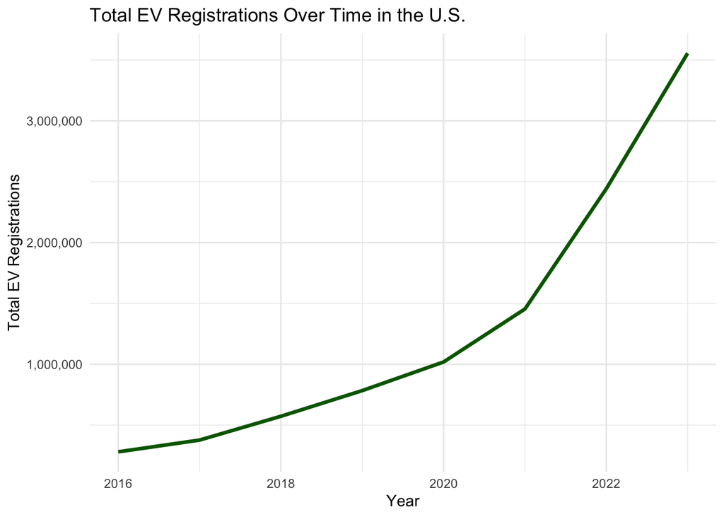

```r
ev_registration_trend <- EV_Data %>%
  group_by(Year) %>%
  summarise(total_ev_registrations = sum(`EV Registrations`, na.rm = TRUE))

ggplot(data = ev_registration_trend, aes(x = Year, y = total_ev_registrations)) +
  geom_line(color = "darkgreen", size = 1.2) +
  labs(
    title = "Total EV Registrations Over Time in the U.S.",
    x = "Year",
    y = "Total EV Registrations"
  ) +
  scale_y_continuous(labels = comma)+
  theme_minimal()
```

#### Context

There has been a surge in environmental consciousness in recent years, this could be a main factor in such a surge. There is also incentives offered by the government to make purchasing an EV more enticing. These factors will be back with actual analysis.

## EV Stations in the U.S over time

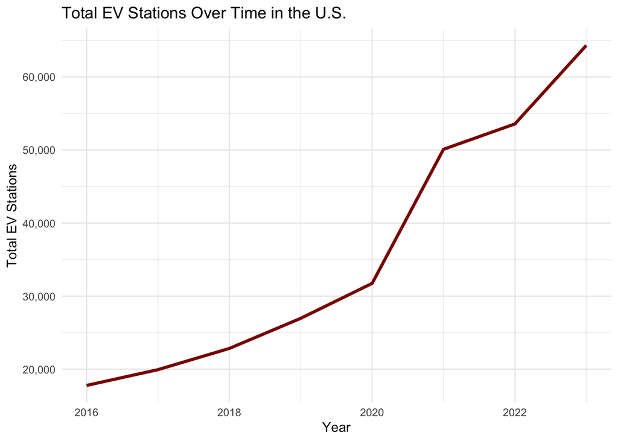

```r
ev_station_trend <- EV_Data %>%
  group_by(Year) %>%
  summarise(total_ev_station = sum(`Stations`, na.rm = TRUE))

ggplot(data = ev_station_trend, aes(x = Year, y = total_ev_station)) +
  geom_line(color = "darkred", size = 1.2) +
  labs(
    title = "Total EV Stations Over Time in the U.S.",
    x = "Year",
    y = "Total EV Stations"
  ) +
  scale_y_continuous(labels = comma)+
  theme_minimal()
```

#### Observation

There was an rapid creation of EV stations to accommodate for the surge in EV usage. Also, there was a huge increase in 2020 and 2021.

#### Context

The surge between 2020 and 2021 can be attributed to common factors such as policy shifts, economic recovery, consumer trends, and technological investment.

U.S. passed legislation and made executive orders under the Biden administration aiming to expand EV charging networks rapidly.

Many government Set zero-emission vehicle (ZEV) targets and implemented incentive programs.

The lead-up to the COP26 Climate Conference in November 2021 pushed countries to make visible climate action commitments

## Charging stations over time

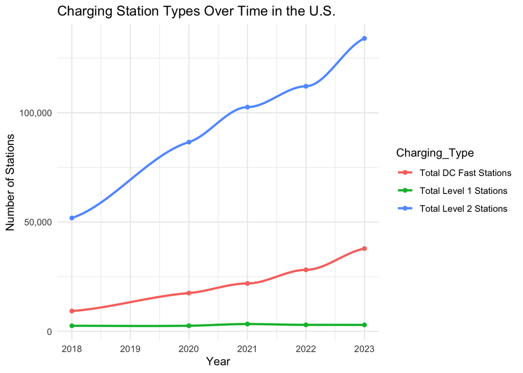

```r
ev_station_charging_type_trend <- complete_states %>%
  group_by(Year) %>%
  summarise(
    `Total Level 1 Stations` = sum(`Level 1`, na.rm = TRUE),
    `Total Level 2 Stations` = sum(`Level 2`, na.rm = TRUE),
    `Total DC Fast Stations` = sum(`DC Fast`, na.rm = TRUE)
    )%>%
  pivot_longer(
    cols = c(`Total Level 1 Stations`, `Total Level 2 Stations`, `Total DC Fast Stations`),
    names_to = "Charging_Type",
    values_to = "Station_Count"
  )

ggplot( data = ev_station_charging_type_trend, aes(x= Year, y= Station_Count, colour = Charging_Type))+
  geom_point()+
  geom_smooth( method = "loess", se= FALSE )+

labs(
  title = "Charging Station Types Over Time in the U.S.",
  x = "Year",
  y = "Number of Stations",
  colour = "Charging_Type"
) +
  scale_y_continuous(labels = comma)+
  theme_minimal()
```

#### Observation

Level 1 charging was used at a constat rate till a decline starting in 2021. Level 2 charging was widely adopted and is on an increasing trend. Lastly, DC fast charging stations are steadly being made across the country.

#### Context

Level 1 charging is phasing out as a primary method due to slow speed and evolving user needs. Level 2 is now dominant, with widespread adoption and continued growth supported by infrastructure investment. DC Fast Charging is expanding gradually but strategically, essential for highway networks and rapid urban charging.

## Total incentives granted over time in the U.S.

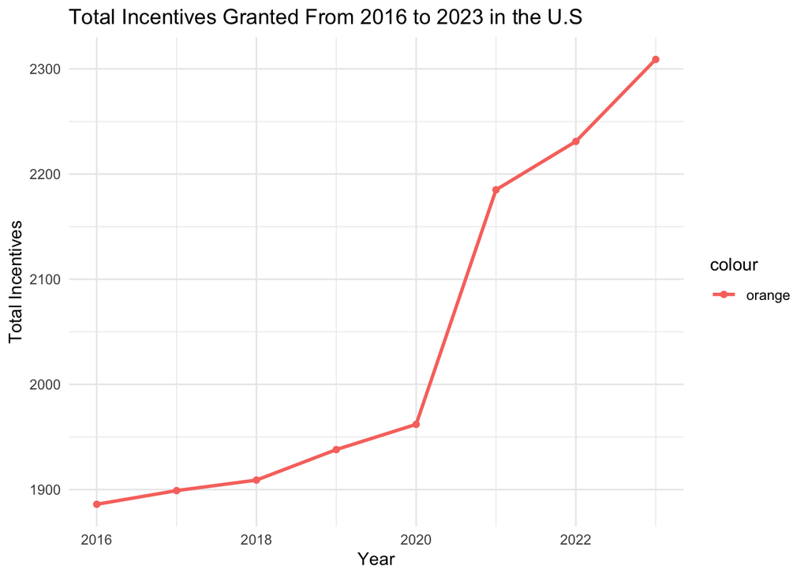

```r
total_incentives_trend <- EV_Data %>%
  group_by(Year) %>%
  summarise(`Total Incentives` =sum(`Incentives`, na.rm = TRUE))

ggplot( data =total_incentives_trend, aes(x= Year, y= `Total Incentives`, colour = "orange" ))+
  geom_point()+
  geom_line( size = 1)+
  labs(
    title = "Total Incentives Granted From 2016 to 2023 in the U.S"
  )+
  theme_minimal()
```

#### Observation

Starting with a slow growth, in 2020, there was a surge in inectives granted in the U.S

#### Context

This was discussed earlier. Check “EV Stations in the U.S over time” section.

## Total Vehicles and EVs in the U.S from 2016 to 2023

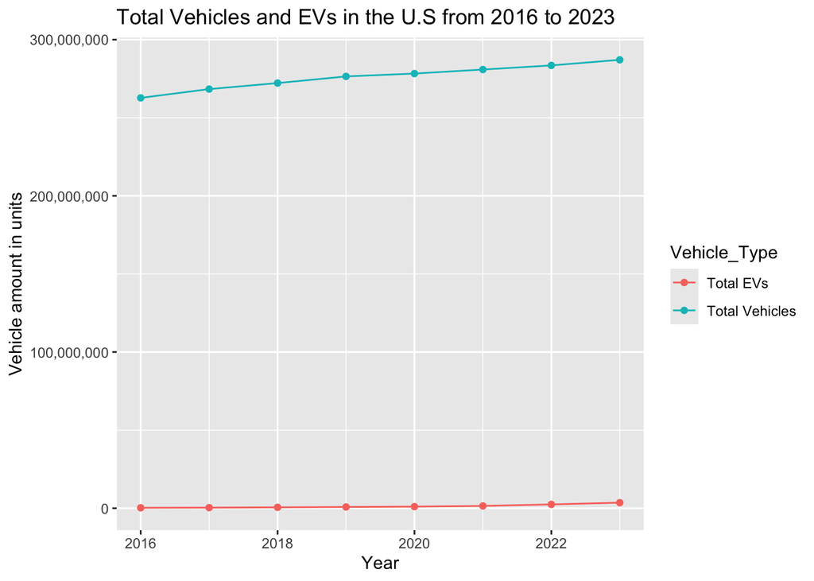

```r
`total_EVs&vehicles` <- `EV_Data` %>%
  group_by(Year) %>%
  summarise( `Total Vehicles`= sum(`Total Vehicles`,na.rm = TRUE),
             `Total EVs`= sum(`EV Registrations`,na.rm = TRUE)
             )%>%
  pivot_longer(
    cols = c(`Total Vehicles`, `Total EVs`),
    names_to = "Vehicle_Type",
    values_to = "Count"
  )

ggplot( data = `total_EVs&vehicles`, aes(x= Year, y= Count, colour = Vehicle_Type ))+
  geom_point() +
  geom_line()+
  scale_y_continuous(labels = comma)+
  labs(
    title = "Total Vehicles and EVs in the U.S from 2016 to 2023",
     y = "Vehicle amount in units"
  )
```

```r
  theme_minimal()
```

[output not shown]

[output not shown]

#### Context

Pricing is a big factor in the amount of EVs on the road in the U.S. The average EV price in the U.S is $55,000 ( as of 2025) For many this is steep, yet in older years it was more expensive. It is slowly becoming cheaper.

## Median EV % share from 2016 to 2023

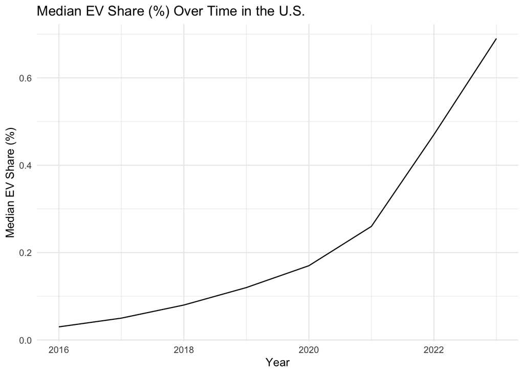

```r
median_ev_share <- `EV_Data` %>%
  group_by(Year) %>%
  summarise(`Median EV Share (%)`= median(`EV Share (%)`), na.rm = TRUE)


ggplot( data =`median_ev_share`, aes(x= Year, y= `Median EV Share (%)`))+
  geom_line()+
  labs(
    title = "Median EV Share (%) Over Time in the U.S.",
    x = "Year",
    y = "Median EV Share (%)"
  )+
  scale_y_continuous(labels = scales::label_number(accuracy = 0.1))+
  theme_minimal()
```

#### Context

It can be attributed to early policy incentives, growing consumer interest, and the emergence of competitive EV models.

## Distribution of EV share (%) in 2016 compared to 2023.

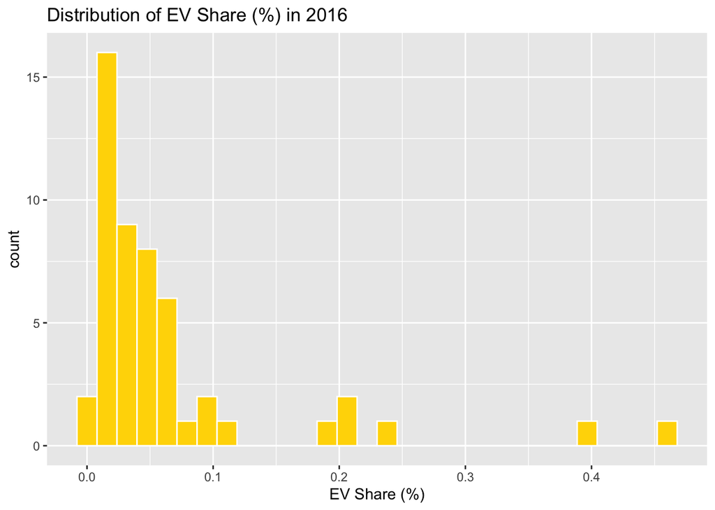

```r
EV_Data %>%
  filter(Year == 2016) %>%
  ggplot(aes(x = `EV Share (%)`)) +
  geom_histogram(bins = 30, fill = "gold", color = "white") +
  labs(title = "Distribution of EV Share (%) in 2016")
```

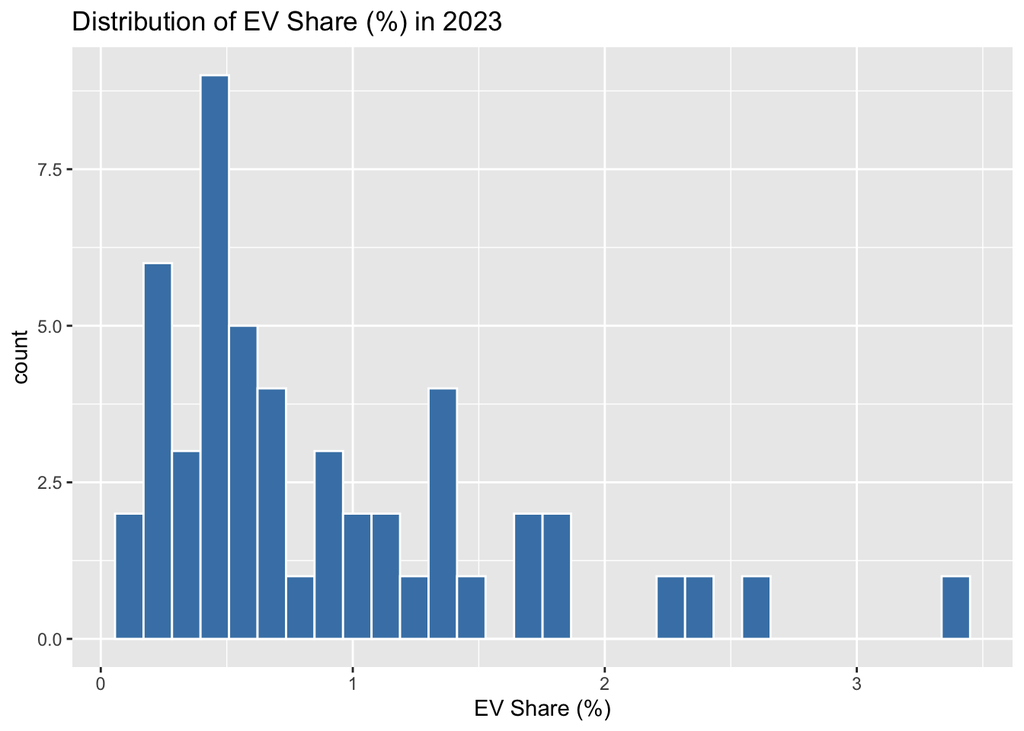

```r
EV_Data %>%
  filter(Year == 2023) %>%
  ggplot(aes(x = `EV Share (%)`)) +
  geom_histogram(bins = 30, fill = "steelblue", color = "white") +
  labs(title = "Distribution of EV Share (%) in 2023")
```

#### Observation

This distribution highlights how rare EV were in 2016 in contrast to it being more common in 2023.

#### Context

This was discussed earlier. Check “EV Stations in the U.S over time” section.

##Summary of EV Share (%) and a boxplot graph

```r
summary(EV_Data$`EV Share (%)`)
```

```
##    Min. 1st Qu.  Median    Mean 3rd Qu.    Max.
##  0.0000  0.0600  0.1650  0.3289  0.4100  3.4100
```

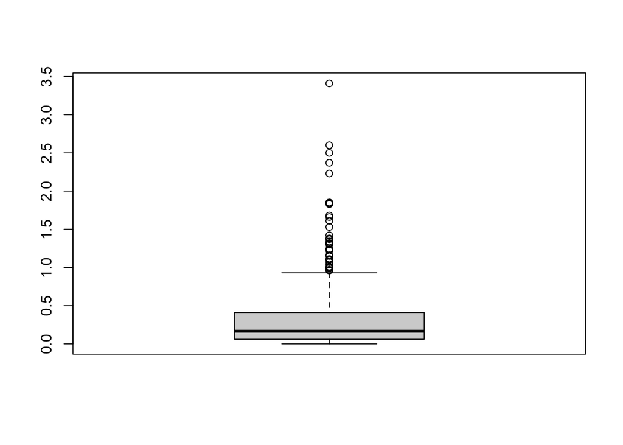

```r
boxplot(EV_Data$`EV Share (%)`)
```